# MoBPS (1.15.40)

Torsten Pook

2026-11-11

This file descripts all updates of the software since 1.15.20. Most updates on smaller features to make breeding value estimation more efficient, convinient, reproducable, flexible

## Validation tools for MiXBLUP

MoBPS now allows to generate validation statistics from the R-packages validatoR and TuttiFrutti. validatoR can be activated through bve.validator = TRUE and will display validation statistics of the EBVs against the underlying true genetic values. A convergence plot (adapted from the R-package TuttiFrutti while using base-plot) can be generated through mixblup.convergence.

```r
library(MoBPS)
population = creating.diploid(nsnp = 1000, nindi = 100, n.additive = c(100,100), chr.nr = 5)

for(index in 1:5){
  population = breeding.diploid(population, breeding.size = 100)
}

population = breeding.diploid(population, phenotyping = "all", heritability = c(0.4,0.1))
```

```r
population = breeding.diploid(population, bve = TRUE, bve.gen = 1:6, bve.validator = TRUE)
```

```
## Start genomic BVE.
## Use Pedigree BLUP (No individuals genotyped!)
## Derive pedigree-matrix based for  600  individuals based on  600  individuals.
## 600 phenotyped individuals for trait: Trait 1.
##  600 phenotyped individuals for trait: Trait 2.
## 600 individuals considered in BVE.
## Variance components in BVE: sigma_g^2 = 44.0039; sigma_e^2 = 68.3498 ; h^2 = 0.392
##  Variance components in BVE: sigma_g^2 = 36.8373; sigma_e^2 = 312.5344 ; h^2 = 0.105
## Estimated fixed effects:
##          [,1]     [,2]
## [1,] 98.53371 101.9381
## 0.06 seconds for BVE.
## Correlation between genetic values and BVE:
## 0.7254509 0.4228443
##                 Trait 1     Trait 2
## n           600.0000000 600.0000000
## correlation   0.7254509   0.4228443
## slope         1.0378114   0.9407346
## intercept    -3.3949552   6.4590567
## mean_diff    -0.3651526  -0.4136867
## mse          20.9748536  30.3976892
## rmse          4.5798312   5.5134099
```

```r
setwd("C:/Users/pook001/OneDrive - Wageningen University & Research/") # adapt both for location of mixblup
population = breeding.diploid(population, bve = TRUE, bve.gen = 1:6, mixblup.path = "MiXBLUP/MiXBLUP.exe",
                              mixblup.convergence = TRUE, mixblup.bve = TRUE)
```

```
## Start genomic BVE.
## Use Pedigree BLUP (No individuals genotyped!)
## Start writting pedigree file at MiXBLUP_files/pedigree.txt
## Start collecting pedigree
## Pedigree contains 600 animals with 0 animals without known parents
## Start writting: MiXBLUP_files/pedigree.txt
```

```
## Start writting parfile at MiXBLUP_files/parfile.txt
## Variance components in BVE: sigma_g^2 = 44.0039; sigma_e^2 = 68.3498 ; h^2 = 0.392 (Trait: Trait 1)
## Variance components in BVE: sigma_g^2 = 36.8373; sigma_e^2 = 312.5344 ; h^2 = 0.105 (Trait: Trait 2)
## Start writting datafile at MiXBLUP_files/data.txt
```

```
## Start writting input file at MiXBLUP_files/InpMiXBLUP.txt
## 600 phenotyped individuals in BVE (Trait: Trait 1).
## 600 individuals considered in BVE.
## 600 phenotyped individuals in BVE (Trait: Trait 2).
## 600 individuals considered in BVE.
## Start MiXBLUP BVE
## Remove previous Solani file!
## Finished preparation of MiXBLUP files.
##  Preparation took 0.09 seconds.
## Finished MiXBLUP BVE
## Estimate took 4.24 seconds.
## MiXBLUP solver info:
##     CD convergence criterion 0.1E-4 achieved in 46 iterations.
##     Solutions have converged according to CD criterion.
```

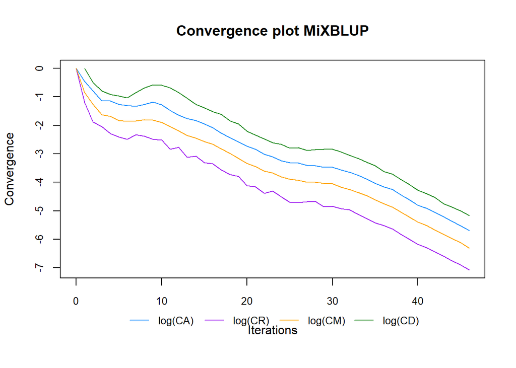

```
## Correlation between genetic values and BVE:
## 0.7254514 0.4228381
```

## MoBPS internal breeding value estimation

Two new breeding value estimations were introduced. Default is to use the multi-trait model when working with more than 1 trait, the new single-trait model is used in a single trait evaluation. In case reliabilities or SNP-effects need to be estimated through backsolving, the old pipeline is used. When including both fixed effects and needed to estimate SNP effects, the use of rrblup / MiXBLUP is recommended.

### MoBPS single-trait breeding value estimation

The internal MoBPS solver now supports a single-trait breeding value estimation that includes the estimation of fixed effects that can be activated by setting mobps.single.bve = TRUE

```r
library(MoBPS)
# For two-trait models, it is sufficent to just provide a value instead of a correlation matrix
population = creating.diploid(nsnp = 1000, nindi = 100, n.additive = c(100,100), chr.nr = 5,
                              trait.cor = 0.6)

for(index in 1:5){
  population = breeding.diploid(population, breeding.size = 100)
}

population = breeding.diploid(population, phenotyping = "all", heritability = c(0.4,0.1))
```

```r
# mobps.multi.bve would have also been the automatically chosen default
population = breeding.diploid(population, bve = TRUE, mobps.multi.bve = TRUE)
```

```
## Start genomic BVE.
## Use Pedigree BLUP (No individuals genotyped!)
## Derive pedigree-matrix based for  100  individuals based on  510  individuals.
## 100 phenotyped individuals for trait: Trait 1.
##  100 phenotyped individuals for trait: Trait 2.
## 100 individuals considered in BVE.
## Variance components in BVE: sigma_g^2 = 34.5034; sigma_e^2 = 62.2117 ; h^2 = 0.357
##  Variance components in BVE: sigma_g^2 = 35.4087; sigma_e^2 = 277.9081 ; h^2 = 0.113
## Estimated fixed effects:
##          [,1]     [,2]
## [1,] 114.7517 117.5947
## 0 seconds for BVE.
## Correlation between genetic values and BVE:
## 0.6666066 0.5295287
```

```r
population = breeding.diploid(population, bve = TRUE, mobps.single.bve = TRUE)
```

```
## Start genomic BVE.
## Use Pedigree BLUP (No individuals genotyped!)
## Derive pedigree-matrix based for  100  individuals based on  510  individuals.
## Perform breeding value estimation using separate single trait models.
##  Use mobps.multi.bve = TRUE or use external software blupf90 or MiXBLUP for multi-trait models.
##  100 phenotyped individuals in BVE (Trait: Trait 1).
## 100 individuals considered in BVE.
## Variance components in BVE: sigma_g^2 = 34.5034; sigma_e^2 = 54.432 ; h^2 = 0.388
## Estimated fixed effects: 114.7541
## 100 phenotyped individuals in BVE (Trait: Trait 2).
## 100 individuals considered in BVE.
## Variance components in BVE: sigma_g^2 = 35.4087; sigma_e^2 = 356.3177 ; h^2 = 0.09
## Estimated fixed effects: 117.5888
## Correlation between genetic values and BVE:
## 0.6388844 0.4599486
```

```r
population = breeding.diploid(population, bve = TRUE, mobps.bve = TRUE)
```

```
## Start genomic BVE.
## Use Pedigree BLUP (No individuals genotyped!)
## Derive pedigree-matrix based for  100  individuals based on  510  individuals.
## Perform breeding value estimation using separate single trait models.
##  Use mobps.multi.bve = TRUE or use external software blupf90 or MiXBLUP for multi-trait models.
##  100 phenotyped individuals in BVE (Trait: Trait 1).
## 100 individuals considered in BVE.
## Variance components in BVE: sigma_g^2 = 34.5034; sigma_e^2 = 54.432 ; h^2 = 0.388
## 0 seconds for BVE.
## 100 phenotyped individuals in BVE (Trait: Trait 2).
## 100 individuals considered in BVE.
## Variance components in BVE: sigma_g^2 = 35.4087; sigma_e^2 = 356.3177 ; h^2 = 0.09
## 0 seconds for BVE.
## Correlation between genetic values and BVE:
## 0.6386581 0.45977
```

## Inserting EBVs for selected traits

A multi-trait evaluation, does not have to necessarily enter EBVs for all traits anymore. Default remains to enter EBVs for all but a subset can be selected through bve.insert.traits.

Additionally, its now possible to not only selected which traits to include by discard specific ones in bve.ignore.traits but also indicate which to include bve.include.traits instead. These traits are included in the evaluation - EBVs are entered based on bve.insert.traits (with default being to take all that were included)

## LIS

Integration of LIS to allow for the simulation of complex behavioural phenotypes and social interactoins in group-housed animals (https://github.com/CiaranWang/LIS/tree/master). LIS-based traits can be added using the function add.lis() and any phenotyping call in breeding.diploid() will automatically call LIS software to generate respective phenotypes.

```r
library(MoBPS)

population = creating.diploid(nsnp = 10000, chr.nr = 10, nindi = 280,
                              tracking = TRUE)

population = add.lis(population,
                     bit.performer.trait = TRUE,
                     bit.receiver.trait = TRUE,
                     step = 500,
                     lis.path = "LIS/build/LIS",
                     lis.parameter = "LIS/parameter.ini")

population = breeding.diploid(population, breeding.size = 280,
                              pen.assignments = TRUE,
                              repeat.mating = 14,
                              pen.size = 14,
                              pen.by.sex = TRUE)

population = breeding.diploid(population, phenotyping.gen = get.ngen(population),
                                heritability = 1)
```

## get.inbreeding.snp

Added function to compute SNP-based inbreeding coefficients similar to get.kinship.snp(). As computation of genotypes is the primary cost favor, this does not have the same computational benefits as get.kinship.snp() over get.kinship.emp() and is mostly added for completeness.

```r
library(MoBPS)

population = creating.diploid(nsnp = 10000, chr.nr = 10, nindi = 8)

for(index in 1:10){
  population = breeding.diploid(population, breeding.size = 8)
}
```

```r
# Empirical / Underlying true inbreeding based on recombination
get.inbreeding.emp(population, gen = 11)
```

```
##        81        82        83        84        85        86        87        88
## 0.4661656 0.3327259 0.3779757 0.5386794 0.2995211 0.3407579 0.5687660 0.3747547
```

```r
# Pedigree-based inbreeding
get.inbreeding.exp(population, gen = 11)
```

```
## Derive pedigree-matrix based for  8  individuals based on  63  individuals.
```

```
##        81        82        83        84        85        86        87        88
## 0.4333496 0.2260742 0.3190918 0.4333496 0.2391357 0.2468262 0.4333496 0.3801270
```

```r
# SNP-based approximation of recombination based inbreeding
get.inbreeding.snp(population, gen = 11)
```

```
##     81     82     83     84     85     86     87     88
## 0.4660 0.3320 0.3784 0.5390 0.2985 0.3406 0.5687 0.3750
```

## Run-time

### Generation of new individuals

Multi-core generation of individuals was deactivated (generation.cores = 1) as it does not yield speed-ups. Generation of individuals should currently not be the primary bottleneck - this will be observed / improved in the future

### get.database (Computational efficiency)

Improved efficiency of get.database internally. This will speed up particularly collecting of information for breeding value estimation, like pedigree collection.

### Phenotyping (Computational efficiency)

Improved efficiency of internal simulation of phenotypes.

### Selection (Computational efficiency)

Improved efficiency of selection when working with extremely high number of selection candidates (100.000+)

### get.stats.gen() / get.stats.cohorts()

Calculation of get.stats.gen() and get.stats.cohorts() can skip the calculation of inbreeding as this was by far the calculation that took the most time through skip.inbreeding = TRUE.

## Bug-fixes

ocs.ub now works when providing different thresholds per individual

Improved prints provided during breeding.diploid() to be in-line with underlying operations

export.selected.database = TRUE now exports a database with four columns (instead of 3) –> individuals were correct before, this is just to be in line with database structures used in all other functions

replace.real.bve has been removed from creating.diploid() and is only available in creating.trait()